# HW 1: Warmup

## Getting Help

If you have any questions about the assignment, please post them on Teams!

## Getting started

Click [HERE](https://classroom.github.com/a/eLXKhluX) to claim your repo for this assignment.

First, open the R Markdown document `hw-01-welcome.Rmd` and Knit it. Make sure it compiles without errors. The output will be in the `.md` file with the same name.

The document contains placeholders for the following exercises.

# The Data

Let’s imagine we’re hired by the administrators of the [Capital Bikeshare program](https://www.capitalbikeshare.com) program in Washington D.C., to **help them predict the hourly demand for rental bikes**.. We will be working with this data over the next several homework assignments.

The predicted hourly demand could be used for planning the number of bikes that need to be available in the system at any given hour of the day. It costs the program money if bike stations are full and bikes cannot be returned, or empty and there are no bikes available. You will use multiple linear regression and polynomial regression and will explore techniques for subset selection to predict bike usage. Our eventual goal will be to build a regression model that can predict the total number of bike rentals in a given hour of the day, based on all the information we can get.

The data for this problem were collected from the Capital Bikeshare program over the course of two years (2011 and 2012). Researchers at the University of Porto processed the data and augmented it with extra information, as described [on this page](https://archive.ics.uci.edu/ml/datasets/bike+sharing+dataset). It has been cleaned up slightly for this assignment.

## Load and Explore Data

```r
daily_rides <- read_csv("data/day_simple.csv")
```

Practice reading that out loud: “`daily_rides` gets `read_csv` of `data/day_simple.csv`.” (That’s a *forward* slash.)

1. Take a quick look at the data: you’ll write R code that will be read “take `daily_rides` and then `glimpse()` it.”

✅ ⬆️ *Now is a good time to commit and push your changes to GitHub with an appropriate commit message. Make sure to commit and push all changed files so that your Git pane is cleared up afterwards.*

3. Create a scatter plot showing the number of rides by *registered* users each day. Sample code is provided below, but you will need to fill in the blanks.

```r
ggplot(data = ____, mapping = aes(x = ___, y = ___)) +
  geom_point() +
  geom_smooth() +
  labs(x = "___", y = "___")
```

Let’s deconstruct this code:

- `ggplot()` is the function we are using to build our plot, in layers.
- In the first layer we always define the data frame as the first argument. Then, we define the mappings between the variables in the dataset and the **aes**thetics of the plot (e.g. x and y coordinates, colors, etc.).
- In the next layer we represent the data with **geom**etric shapes, in this case with points.
- In the next layer we add a smoothing “trend” line. (Try removing `geom_point()` and `geom_smooth()` one at a time to make sure you understand what each one does.)
- Finally, we make the visualization more hospitable by adding labels for each aesthetic of the plot.

The result should look like:

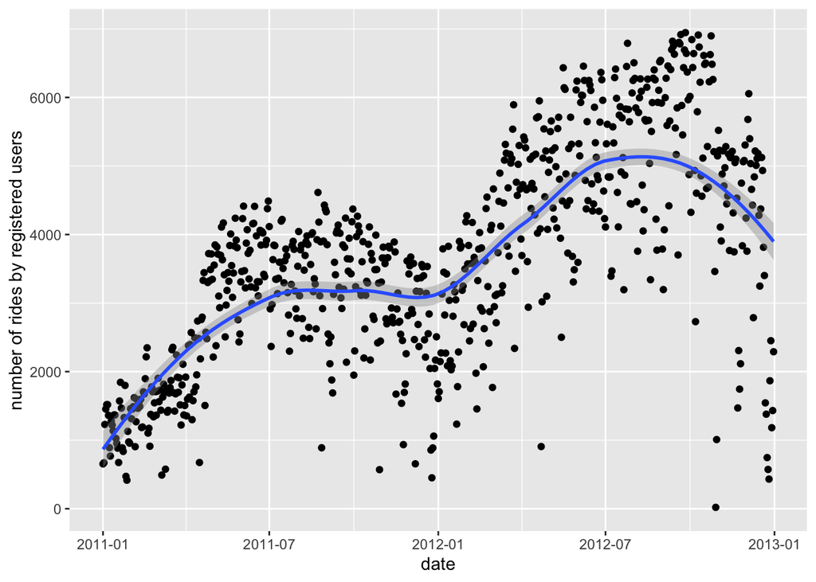

✅ ⬆️ *Commit and push your changes again.*

4. Make the same plot again here, but add a mapping of `workingday` to the `color` aesthetic. Your result should look like:

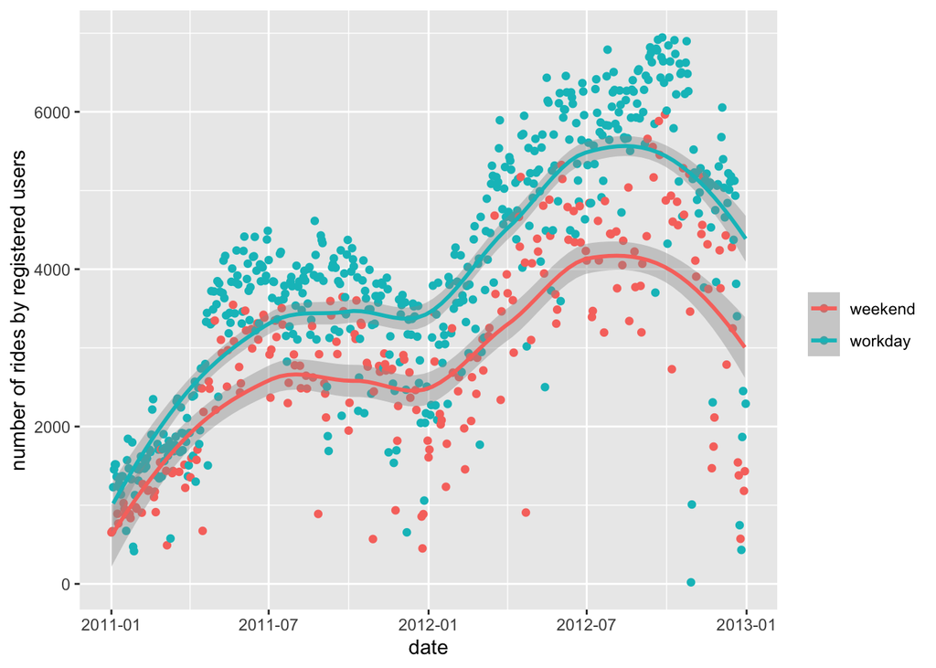

5. Write a one or two sentence interpretation of the graph, focusing on the following question: *How do the number of rides by registered users compare for weekdays vs weekends?*
6. Make a scatter plot showing the how the number of rides by registered users varies with temperature. Design the plot so that it shows the difference between weekends and weekdays.

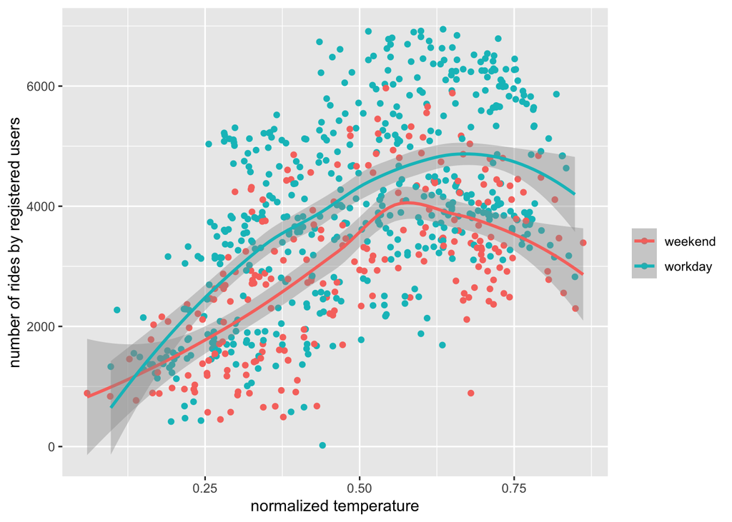

✅ ⬆️ *Commit and push your changes again.*